# Lab 4: Childcare Costs in California

Author

Yanna Shirokova

Published

October 15, 2024

## The Data

In this lab we’re going look at the median weekly cost of childcare in California. A detailed description of the data can be found [here](https://github.com/rfordatascience/tidytuesday/blob/master/data/2023/2023-05-09/readme.md).

The data come to us from [TidyTuesday](https://github.com/rfordatascience/tidytuesday).

**0. Load the appropriate libraries and the data.**

```r
library(tidyverse)
library(forcats)
library(RColorBrewer)
```

```r
childcare_costs <- read_csv('https://raw.githubusercontent.com/rfordatascience/tidytuesday/master/data/2023/2023-05-09/childcare_costs.csv')

counties <- read_csv('https://raw.githubusercontent.com/rfordatascience/tidytuesday/master/data/2023/2023-05-09/counties.csv')
```

**1. Briefly describe the dataset (~ 4 sentences). What information does it contain?**

In this lab we’re going look at the median weekly cost of childcare in California.

The childcare_costs data set looks at various counties and provides information on unemployment rates, labor force participation rates, poverty rates, medium earnings/ income, total population count, race, number of households, employment/ type of jobs, and childcare care rates for different groups. The counties data set looks at various counties and provides information on their name, state, and two letter abbreviation.

Together, these data sets allow us to analyze and compare counties in terms of employment, poverty, household income, and childcare costs, offering insights into the economic factors that may influence childcare affordability across different regions. So, they help analyze the relationship between childcare costs and various socioeconomic factors across U.S. counties.The data came from market rate surveys and the American Community Survey (ACS) and was collected to understand childcare affordability and access, to support families and make changes in needed

## California Childcare Costs

Let’s start by focusing only on California.

```r
ca_childcare <- childcare_costs |>
  inner_join(counties, by = "county_fips_code") |>
  filter(state_abbreviation == "CA")

# REFLECTION/ GROWING
# Before I was outputting the data set at each stage. This is unnecessary. I don't
# need to include outputs that don't show relevant information as this can
# clutter my document.
```

**3. Using a function from the `forcats` package, complete the code below to create a new variable where each county is categorized into one of the [10 Census regions](https://census.ca.gov/regions/) in California. Use the Region description (from the plot), not the Region number.**  
*Hint: This is probably a good place to use ChatGPT to reduce on tedious work. But you do need to know how to prompt ChatGPT to make it useful!*

```r
ca_childcare_clean <- ca_childcare |> # keep
  mutate(county_name = str_remove(county_name, " County")) |> # keep
  mutate(region =
    fct_collapse(county_name,
      "Superior California" = c("Butte", "Colusa", "El Dorado", "Glenn", "Lassen", "Modoc",
      "Nevada", "Placer", "Plumas", "Sacramento", "Shasta", "Sierra", "Siskiyou", "Sutter",
      "Tehama", "Yolo", "Yuba"),
      "North Coast" = c("Del Norte", "Humboldt", "Lake", "Mendocino", "Napa", "Sonoma", "Trinity"),
      "San Francisco Bay Area" = c("Alameda", "Contra Costa",
      "Marin", "San Francisco", "San Mateo", "Santa Clara", "Solano"),
      "Northeren San Joaquin Valley" = c("Alpine", "Amador", "Calaveras",
      "Madera", "Mariposa", "Merced", "Mono", "San Joaquin", "Stanislaus", "Tuolumne"),
      "Central Coast" = c("Monterey", "San Benito", "San Luis Obispo", "Santa Barbara", "Santa Cruz", "Ventura"),
      "Southern San Joaquin Valley" = c("Fresno", "Inyo", "Kern", "Kings", "Tulare"),
      "Inland Empire" = c("Riverside", "San Bernardino"),
      "Los Angeles County" = c("Los Angeles"),
      "Orange County" = c("Orange"),
      "San-Diego Imperial" = c("Imperial", "San Diego")))
```

**4. Let’s consider the median household income of each region, and how that income has changed over time. Create a table with ten rows, one for each region, and two columns, one for 2008 and one for 2018. The cells should contain the `median` of the median household income (expressed in 2018 dollars) of the `region` and the `study_year`. Arrange the rows by 2018 values.**

```r
# https://chatgpt.com/share/670f5a38-d3b4-8006-ad62-8769382ddacb
# got a red error from rstudio -- asked what it means -- added .groups = 'drop'

ca_childcare_clean |>
  filter(study_year == 2008 | study_year == 2018) |>
  group_by(region, study_year) |>
  summarise(median_income = median(mhi_2018, na.rm = TRUE), .groups = 'drop') |>
  pivot_wider(id_cols = region,
              names_from = study_year,
              values_from = median_income,
              names_prefix = "Income ") |>
  arrange(`Income 2018`)
```

```
# A tibble: 10 × 3
   region                       `Income 2008` `Income 2018`
   <fct>                                <dbl>         <dbl>
 1 North Coast                         47862.        45528
 2 Southern San Joaquin Valley         52676.        52479
 3 Superior California                 57831.        53270
 4 Northeren San Joaquin Valley        59108.        57769
 5 San-Diego Imperial                  58201.        60344.
 6 Inland Empire                       65977.        62056
 7 Los Angeles County                  63471.        64251
 8 Central Coast                       72979         74849
 9 Orange County                       86452.        85398
10 San Francisco Bay Area              90412.       104552
```

**5. Which California `region` had the lowest `median` full-time median weekly price for center-based childcare for infants in 2018? Does this `region` correspond to the `region` with the lowest `median` income in 2018 that you found in Q4?**  
*Hint: The code should give me the EXACT answer. This means having the code output the exact row(s) and variable(s) necessary for providing the solution.*

```r
 ca_childcare_clean |>
  filter(study_year == 2018) |>
  group_by(region) |>
  summarise(med_price = median(mc_infant, na.rm = TRUE)) |>
  filter(med_price == min(med_price))
```

```
# A tibble: 1 × 2
  region              med_price
  <fct>                   <dbl>
1 Superior California      215.
```

**6. The following plot shows, for all ten regions, the change over time of the full-time median price for center-based childcare for infants, toddlers, and preschoolers. Recreate the plot. You do not have to replicate the exact colors or theme, but your plot should have the same content, including the order of the facets and legend, reader-friendly labels, axes breaks, and a loess smoother.**

```r
# https://chatgpt.com/share/6710bf20-da7c-8006-9a2d-850e8997cd0a
# Chat GPT: Looked up examples and applied them to my code on my
# Looked up what "loess smoother"
# Looked up how to put graphs next to each other -- facet_wrap()
# Looked up how to change axis -- make y go up by 100 (start at 100, end at 500)
# and the x axis so it includes 2008-2018 and goes up by 2 years
# Looked up how to separate graphs a little
# Looked up how to adjust size of text and line/ dots
# Looked up how to change text size
# https://chatgpt.com/share/671b1f58-e52c-8006-a097-3d05613a1ebc
# ^ for coloring

# GROWING/ REFLECTION:
# Before I changed the names of mc_infant, mc_toddler, mc_preschool
# to Infant, Toddler, Preschool using recode(), which is
# superseeded! I changed it to case_when() from the forcats package. This way
# I am using the updated appropriate function. I also changed the size of my
# legend to be smaller, as it was massive before. This makes the graph more
# pleasing to look at. Lastly, I added the theme theme_bw() and modified the
# colors. Rather than using the defaults, it is important to explore different
# colors and themes that can make a graph more appealing!

ca_childcare_long <- ca_childcare_clean |>
  select(study_year, region, mc_infant, mc_toddler, mc_preschool) |>
  # Transform wide to long format
  pivot_longer(cols = starts_with("mc_"),
               # Create a new column "age" from the column names
               names_to = "age",
               # The corresponding values will go in the "price" column
               values_to = "price") |>
  mutate(age = fct_relevel(case_when(
    age == "mc_infant" ~ "Infant",
    age == "mc_toddler" ~ "Toddler",
    age == "mc_preschool" ~ "Preschool"
  ), "Infant", "Toddler", "Preschool"))
ca_childcare_long
```

```
# A tibble: 1,914 × 4
   study_year region                 age       price
        <dbl> <fct>                  <fct>     <dbl>
 1       2008 San Francisco Bay Area Infant     302.
 2       2008 San Francisco Bay Area Toddler    214.
 3       2008 San Francisco Bay Area Preschool  214.
 4       2009 San Francisco Bay Area Infant     313.
 5       2009 San Francisco Bay Area Toddler    234.
 6       2009 San Francisco Bay Area Preschool  234.
 7       2010 San Francisco Bay Area Infant     313.
 8       2010 San Francisco Bay Area Toddler    235.
 9       2010 San Francisco Bay Area Preschool  235.
10       2011 San Francisco Bay Area Infant     314.
# ℹ 1,904 more rows
```

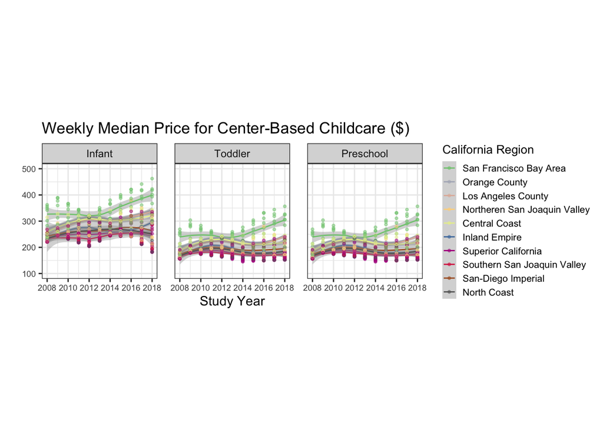

```r
ggplot(data = ca_childcare_long, aes(x = study_year, y = price,
  color = fct_reorder2(.f = region, .x = study_year, .y = price))) +
  geom_smooth(method = "loess", linewidth = 0.5) +
  geom_point(size = 0.8, alpha = 0.5) +
  # creates seperate graphs for age_groups
  # each has its own x-axis
  # in one row
  facet_wrap(~ age, scales = "free_x", nrow=1) +
  labs(title = "Weekly Median Price for Center-Based Childcare ($)",
       x = "Study Year",
       y = "",
       color = "California Region") +
  # adjust axis
  scale_y_continuous(limits = c(100, 500), breaks = seq(100, 500, by = 100)) +
  scale_x_continuous(breaks = seq(2008, 2018, by = 2)) +
  theme_bw() +
  theme(
    # spaces the graphs apart, lines is a unit
    panel.spacing = unit(1, "lines"),
    # change the aspect ratio to make it less tall
    aspect.ratio = 1, # make it less tall
    axis.text.x = element_text(size = 7),
    axis.text.y = element_text(size = 7),
    legend.title = element_text(size = 10),
    legend.text = element_text(size = 8),
    legend.key.size = unit(0.8, "lines")
  ) +
  scale_color_manual(values = colorRampPalette(brewer.pal(8, "Accent"))(10))
```

## Median Household Income vs. Childcare Costs for Infants

**7. Create a scatterplot showing the relationship between median household income (expressed in 2018 dollars) and the full-time median weekly price charged for center-based childcare for an infant in California. Overlay a linear regression line (lm) to show the trend.**

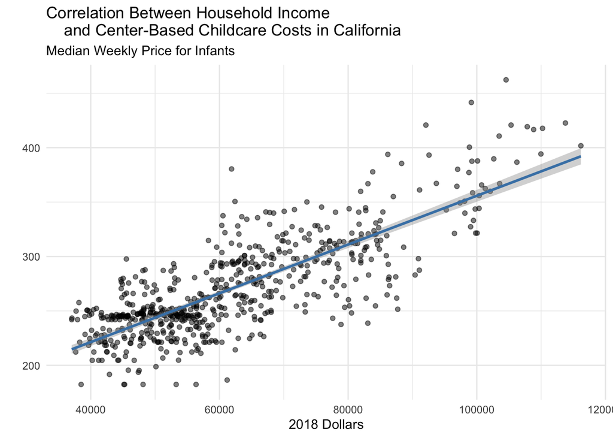

```r
ggplot(data = ca_childcare, aes(x = mhi_2018, y = mc_infant)) +
  geom_point(alpha = 0.5) +
  geom_smooth(method = "lm", color = "steelblue") +
  labs(
    title = "Correlation Between Household Income
    and Center-Based Childcare Costs in California",
    y = "",
    x = "2018 Dollars",
    subtitle = "Median Weekly Price for Infants"
  ) +
  theme_minimal()
```

**8. Look up the documentation for `lm()` and fit a linear regression model to the relationship shown in your plot above.**

```r
# complete the code provided

reg_mod1 <- lm(mc_infant ~ mhi_2018, data = ca_childcare)
summary(reg_mod1)
```

```
Call:
lm(formula = mc_infant ~ mhi_2018, data = ca_childcare)

Residuals:
    Min      1Q  Median      3Q     Max
-82.407 -15.606   0.097  15.999 110.026

Coefficients:
             Estimate Std. Error t value Pr(>|t|)
(Intercept) 1.317e+02  4.321e+00   30.49   <2e-16 ***
mhi_2018    2.241e-03  6.737e-05   33.26   <2e-16 ***
---
Signif. codes:  0 '***' 0.001 '**' 0.01 '*' 0.05 '.' 0.1 ' ' 1

Residual standard error: 27.48 on 636 degrees of freedom
Multiple R-squared:  0.635, Adjusted R-squared:  0.6344
F-statistic:  1106 on 1 and 636 DF,  p-value: < 2.2e-16
```

**9. Using the output from `summary()`, write out the estimated regression line (recall: $y = mx + b$).**

GROWING/ REFLECTION: Before I just had y = (2.241e-03)x + 1.317e+02, which includes no context about what this equation means. The notation I used also made it hard to understand what the numbers actually were. I changed the equation to not be in scientific notation so one could easily read the numbers. I also added context about what the numbers and variables in this equation actually mean. Why have an equation when you don’t consider the context, or the importance of it!

y= 0.002241x + 131.7

y represents the weekly median cost of center-based childcare for infants.  
x represents the median household income in 2018 dollars. The equation implies that for each additional dollar of median household income in 2018, the weekly median cost of childcare increases by about $0.002241. If a household income is $0, their childcare cose is $131.7. This is high considering a family may not be making money!

**10. Do you have evidence to conclude there is a relationship between the median household income and the median weekly cost of center-based childcare for infants in California? Cite values from your `summary()` output to support your claim!**

Yes. The slope is positive, so if the average income a household makes increases, the weekly cost of infant childcare also increases. More specifically, the slope is 2.241e-03, meaning that for every dollar a household makes, the weekly cost of infant goes up by about $0.002241. Next, the p-value is < 2.2e-16, which is smaller than 0.05, which further proves that statistically there is a relationship Between childcare prices and income. The t-value for the mhi_2018 coefficient is 33.26 (t-value for slope), which is large, suggesting the slope is far from 0, or that again household income does have an impact on childcare cost. Lastly, the R-squared value is 0.635, so 63.5% of the childcare cost variability is a result from income.